# CARVE tutorial for R

This tutorial goes through the CARVE R package, on simulated data in part 1 and on the PBMC 3k single-cell data set in part 2. It follows the Python notebooks `Tutorial.ipynb` and `Resolution_Tutorial.ipynb` in this folder and fits at full size, with the default 100 resamples except in the randomized preprocessing fits, which use 60. The package’s vignettes explain the same steps on smaller data: `vignette("CARVE", package = "CARVE")` for the scores and the selection rules, `vignette("single-cell", package = "CARVE")`, `vignette("customizing", package = "CARVE")` and `vignette("python-users", package = "CARVE")`.

Part 1 needs the mclust package, and part 2 also needs Seurat, SeuratObject and dbscan. Part 2 downloads 7 MB from 10x Genomics into `data/` on its first run.

```r
library(CARVE)

n_jobs <- max(1L, parallel::detectCores() - 1L)
n_jobs
```

```
#> [1] 10
```

`n_jobs` is the number of worker processes that share the resamples. Each worker’s random forest gets the machine’s cores divided by the workers, so `n_jobs = 1` leaves the forest every core.

# Part 1: simulated data

## Quick start

Two pairs of interleaved half-moons, 1,000 points in four groups. The groups are curved, so they are not convex clusters.

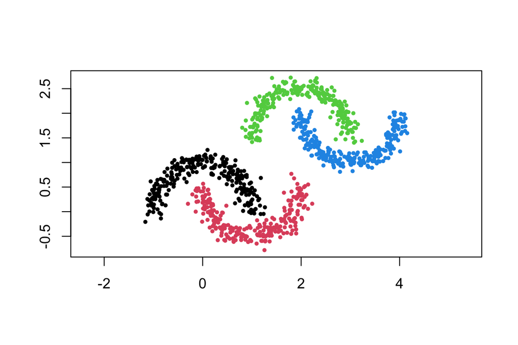

```r
make_moons <- function(n, noise) {
  n_outer <- n %/% 2
  n_inner <- n - n_outer
  t_outer <- seq(0, pi, length.out = n_outer)
  t_inner <- seq(0, pi, length.out = n_inner)
  X <- rbind(cbind(cos(t_outer), sin(t_outer)),
             cbind(1 - cos(t_inner), 1 - sin(t_inner) - 0.5))
  X + matrix(rnorm(2 * n, sd = noise), ncol = 2)
}

set.seed(42)
moons <- rbind(make_moons(500, noise = 0.12),
               make_moons(500, noise = 0.10) + matrix(c(2, 1.5), 500, 2, byrow = TRUE))
moons_truth <- rep(1:4, each = 250)
plot(moons, col = moons_truth, pch = 19, cex = 0.5, asp = 1, xlab = "", ylab = "")
```

```r
moons_grids <- list(
  estimator_grid(AgglomerativeClustering, n_clusters = 2:6, linkage = "ward"),
  estimator_grid(SpectralClustering, n_clusters = 2:6, affinity = "self_tuning")
)
fit_moons <- carve(moons, estimator_param_grids = moons_grids,
                   n_jobs = n_jobs, random_state = 42)
fit_moons
```

```
#> CARVE fit on 1000 samples and 2 features
#> Sweep: n_clusters over 2, 3, 4, 5, 6
#> Estimators: AgglomerativeClustering, SpectralClustering (10 configurations)
#> Resamples: 100 per configuration, subsample_ratio 0.618
#> Mode: default
#> Consensus: exact
```

```r
get_k(fit_moons, measure = "generalizability", rule = "1se", not_two = TRUE)
```

```
#> [1] 3
```

```r
moons_labels <- get_labels(fit_moons, measure = "generalizability", rule = "1se", not_two = TRUE)
table(moons_labels, moons_truth)
```

```
#>             moons_truth
#> moons_labels   1   2   3   4
#>            1 250 250   0   0
#>            2   0   0  35 250
#>            3   0   0 215   0
```

```r
moons_ari <- mclust::adjustedRandIndex(moons_labels, moons_truth)
moons_ari
```

```
#> [1] 0.6401245
```

This fit uses two methods, ward-linkage agglomerative clustering and self-tuning spectral clustering, each with 2 to 6 clusters. The selection scores each configuration by generalizability, takes the largest number of clusters within one standard error of the best (`rule = "1se"`), and leaves two clusters out (`not_two = TRUE`). The two pairs of moons are far apart, so a split into two is easy to reproduce, and the default selection returns 2; the section on two clusters below shows the same effect on other data. With the selection above, CARVE selects 3 clusters, and the labels have an ARI of 0.64 with the four true groups. The table shows that the first pair of moons is one cluster, while the second pair is split into two clusters that follow its moons except for 35 points.

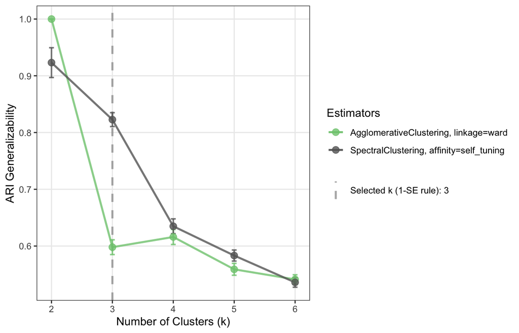

```r
plot_metric_over_n_clusters(fit_moons, measure = "generalizability", rule = "1se", not_two = TRUE)
```

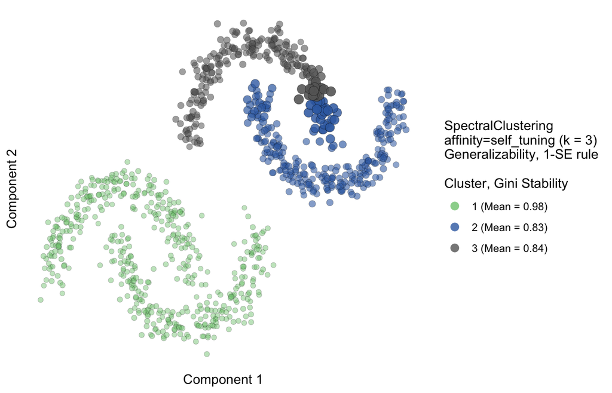

```r
plot_cluster_scatter(fit_moons, measure = "generalizability", rule = "1se", not_two = TRUE)
```

## How CARVE scores a configuration

A configuration is a clustering method, its parameters and a value of the swept parameter, here the number of clusters. For each of `n_resamples` resamples, CARVE draws two overlapping subsamples of `subsample_ratio` of the samples (0.618 by default) and clusters both. Stability is the adjusted Rand index (ARI) between the two clusterings on the samples they share. For generalizability, a random forest trained on one subsample’s clusters predicts the clusters of the samples held out of it, and the ARI compares the prediction with the clusters those samples were given. After the resamples, CARVE builds each configuration’s consensus matrix, the share of the subsamples drawing two samples in which they fell in the same cluster, and computes per-sample scores from it.

```r
results <- estimator_results(fit_moons)
names(results)
```

```
#>  [1] "config_id"                  "method_id"
#>  [3] "method_label"               "estimator"
#>  [5] "linkage"                    "n_clusters"
#>  [7] "sweep_param"                "sweep_value"
#>  [9] "sweep_rank"                 "n_clusters_observed"
#> [11] "n_clusters_observed_se"     "noise_fraction"
#> [13] "ari_stability"              "ari_stability_se"
#> [15] "ari_stability_upper"        "ari_stability_lower"
#> [17] "ari_generalizability"       "ari_generalizability_se"
#> [19] "ari_generalizability_upper" "ari_generalizability_lower"
#> [21] "ari_average"                "ari_average_se"
#> [23] "ari_average_upper"          "ari_average_lower"
#> [25] "affinity"                   "consensus_pac_stability"
#> [27] "consensus_gini_stability"   "consensus_ce_stability"
#> [29] "accuracy_generalizability"
```

```r
results[results$n_clusters == 4,
        c("method_label", "ari_stability", "ari_generalizability",
          "consensus_pac_stability", "consensus_gini_stability", "accuracy_generalizability")]
```

```
#>                               method_label ari_stability ari_generalizability
#> 3    AgglomerativeClustering, linkage=ward     0.6997958            0.6159760
#> 8 SpectralClustering, affinity=self_tuning     0.7631766            0.6348772
#>   consensus_pac_stability consensus_gini_stability accuracy_generalizability
#> 3               0.6747387                0.7582537                 0.7758001
#> 8               0.7117658                0.7999697                 0.7542391
```

`ari_stability` and `ari_generalizability` are means over the resamples, with standard errors (`_se`) and 5th and 95th percentiles (`_lower`, `_upper`). `consensus_pac_stability` is one minus the proportion of ambiguous clustering, the share of consensus entries between 0.05 and 0.95, so higher is better, as for every score in the table. `consensus_gini_stability` and `consensus_ce_stability` average the per-sample stability scores, and `accuracy_generalizability` the per-sample accuracy of the classifier on held-out samples.

## Plots

The eight plots return ggplot objects. The metric plot draws one line per method over the swept values, and the dashed line marks the selection. The quick start passed the selection arguments to it. With the defaults (stability, the 1se rule, two clusters allowed) the dashed line is at 2 clusters:

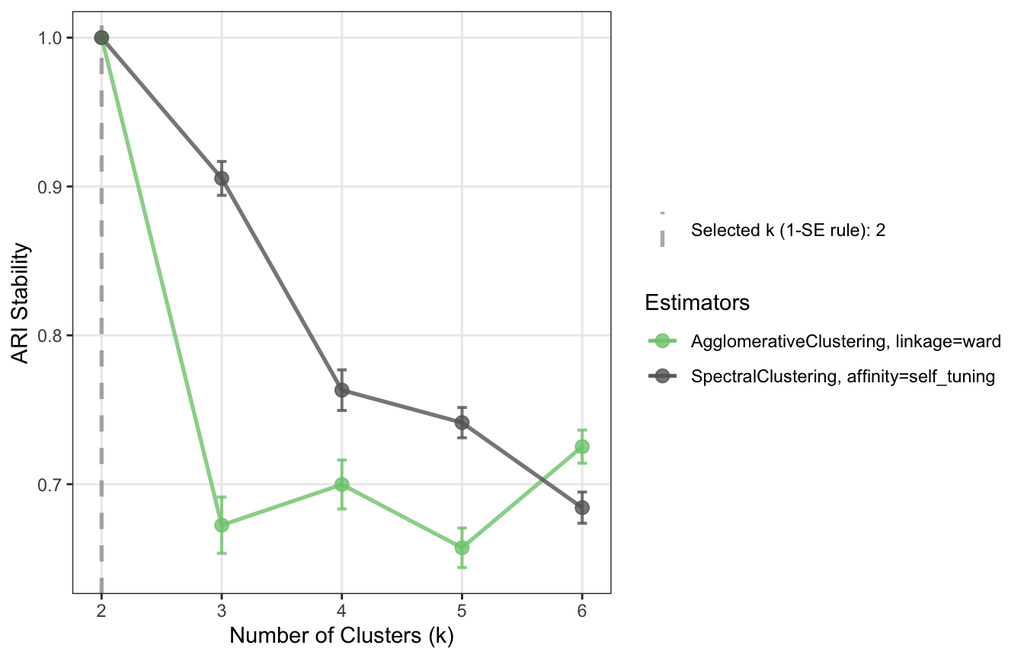

```r
plot_metric_over_n_clusters(fit_moons)
```

`plot_n_clusters_over_sweep()` draws the number of clusters each method returned, averaged over the resamples. It needs a sweep over a parameter other than `n_clusters`, such as a resolution, where the count is an outcome; on an `n_clusters` sweep the count is the swept value itself and the function stops with an error saying so. Part 2 uses it.

The consensus heatmap orders the samples by cluster. `k` shows another number of clusters:

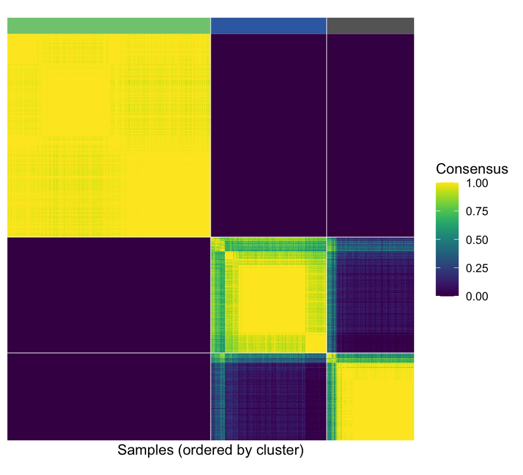

```r
plot_consensus_matrix(fit_moons, measure = "generalizability", rule = "1se", not_two = TRUE)
```

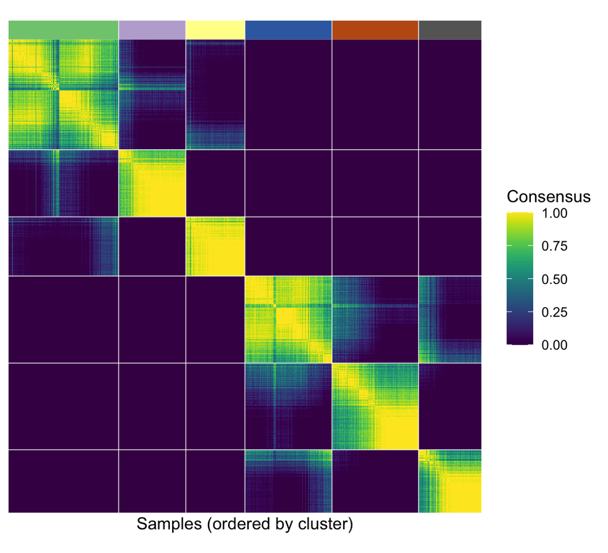

```r
plot_consensus_matrix(fit_moons, k = 6)
```

The per-sample plots show the stability of each sample (`source = "gini"` or `"ce"`) or the share of the draws holding it out in which the classifier predicted its cluster (`source = "accuracy"`):

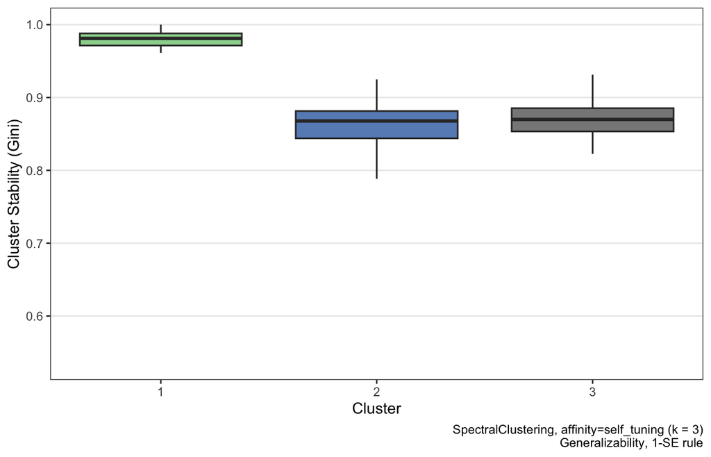

```r
plot_cluster_boxplot(fit_moons, measure = "generalizability", rule = "1se", not_two = TRUE)
```

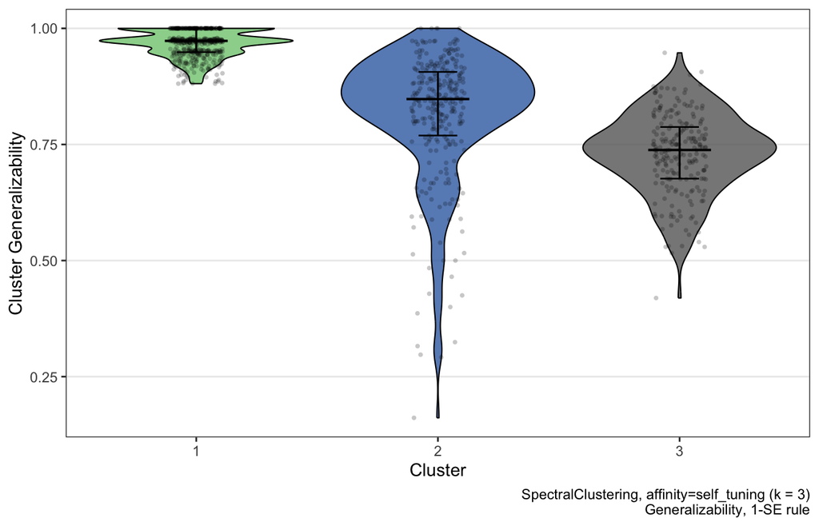

```r
plot_cluster_violin(fit_moons, source = "accuracy", measure = "generalizability", rule = "1se", not_two = TRUE)
```

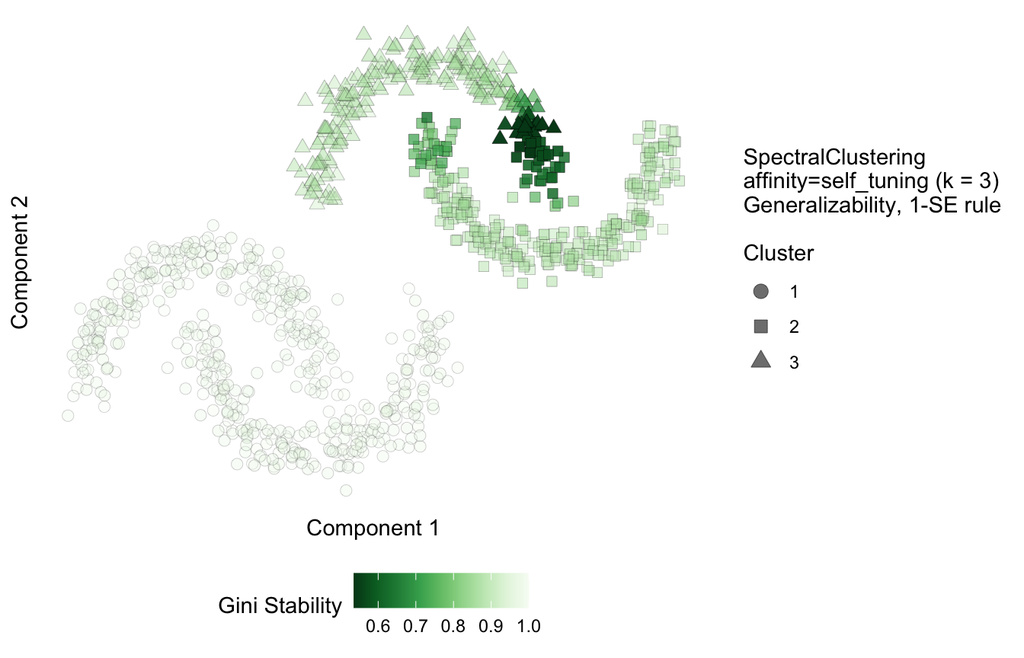

```r
plot_diagnostic_scatter(fit_moons, measure = "generalizability", rule = "1se", not_two = TRUE)
```

`plot_metric_by_pipeline()`, the eighth, is in the section on randomized preprocessing below.

## Selecting a configuration and labeling the samples

```r
c(default = get_k(fit_moons),
  generalizability = get_k(fit_moons, measure = "generalizability", rule = "1se", not_two = TRUE))
```

```
#>          default generalizability
#>                2                3
```

```r
get_sweep_value(fit_moons, measure = "generalizability", rule = "1se", not_two = TRUE)
```

```
#> [1] 3
```

```r
moons_estimator <- get_estimator(fit_moons, measure = "generalizability", rule = "1se", not_two = TRUE)
attributes(moons_estimator)[c("estimator", "params")]
```

```
#> $estimator
#> [1] "SpectralClustering"
#>
#> $params
#> $params$n_clusters
#> [1] 3
#>
#> $params$affinity
#> [1] "self_tuning"
```

```r
table(get_labels(fit_moons, k = 2), moons_truth)
```

```
#>    moons_truth
#>       1   2   3   4
#>   1 250 250   0   0
#>   2   0   0 250 250
```

`get_k(fit_moons)` with the defaults returns 2, and the selection of the quick start returns 3. `get_estimator()` returns the selected method as a function of the data and a seed, and `get_labels(k = 2)` cuts the best configuration at two clusters instead of the selected one. Labels run from 1 to the number of clusters.

## Easy and hard data

Three well-separated groups, and five that overlap:

```r
make_blobs <- function(n_per, centers, sd) {
  truth <- rep(seq_len(nrow(centers)), each = n_per)
  noise <- matrix(rnorm(length(truth) * ncol(centers), sd = sd), ncol = ncol(centers))
  list(X = centers[truth, ] + noise, truth = truth)
}

set.seed(0)
easy <- make_blobs(100, rbind(c(0, 0), c(8, 0), c(4, 7)), sd = 1)
hard <- make_blobs(100, rbind(c(0, 0), c(3, 0), c(1.5, 2.6), c(4.5, 2.6), c(3, 5.2)), sd = 1.2)
fit_easy <- carve(easy$X, n_clusters = 2:8, n_jobs = n_jobs, random_state = 0)
fit_hard <- carve(hard$X, n_clusters = 2:8, n_jobs = n_jobs, random_state = 0)
c(easy = get_k(fit_easy), hard = get_k(fit_hard))
```

```
#> easy hard
#>    3    2
```

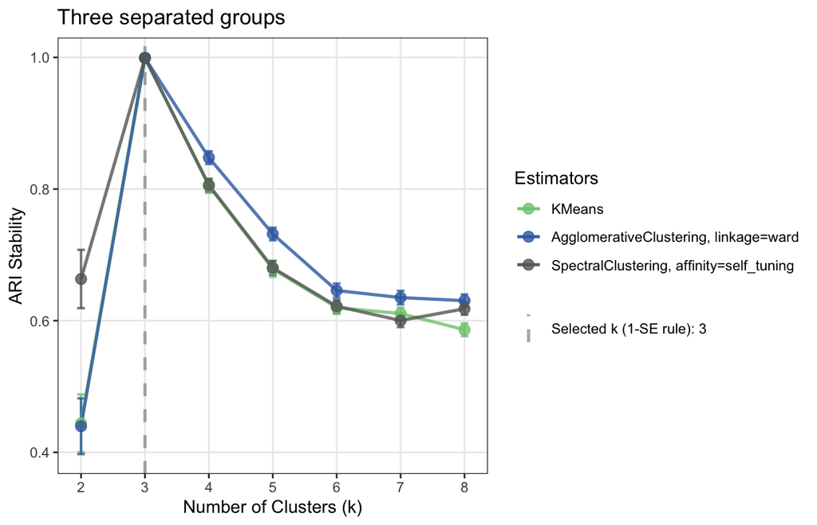

```r
plot_metric_over_n_clusters(fit_easy) + ggplot2::labs(title = "Three separated groups")
```

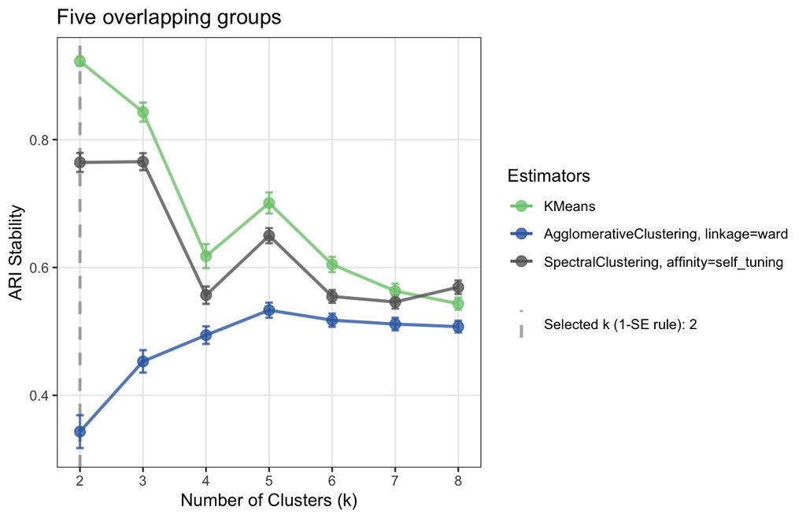

```r
plot_metric_over_n_clusters(fit_hard) + ggplot2::labs(title = "Five overlapping groups")
```

On the easy data the scores of all three methods peak at the true three groups, at an ARI near 1. On the hard data the scores are lower and the methods disagree, and the best score, from k-means, is at two clusters, not at the five true groups.

## The selection rules

The same hard fit under each measure and rule:

```r
measures <- c("stability", "generalizability", "average")
rules <- c("max", "1se", "quantile")
sapply(rules, function(rule) {
  sapply(measures, function(measure) get_k(fit_hard, measure = measure, rule = rule))
})
```

```
#>                  max 1se quantile
#> stability          2   2        3
#> generalizability   2   2        5
#> average            2   2        3
```

`"max"` takes the highest mean score. `"1se"` takes the largest number of clusters whose score is within one standard error of the highest, and `"quantile"` the largest within the 5th to 95th percentiles of the best configuration’s resample scores, so both lean toward finer clusterings when scores are close. On this fit `"max"` and `"1se"` give 2 clusters, whichever measure is used. `"quantile"` gives 3 for stability and 5 for generalizability, so the two scores can point to different numbers of clusters when the rule is looser.

## Two clusters

Four groups in a row can be split into two halves the same way in every resample, so two clusters can score as well as four:

```r
set.seed(1)
line <- make_blobs(75, cbind(c(0, 3, 6, 9), 0), sd = 0.7)
fit_line <- carve(line$X, n_clusters = 2:8, n_jobs = n_jobs, random_state = 1)
c(max = get_k(fit_line, rule = "max"),
  max_not_two = get_k(fit_line, rule = "max", not_two = TRUE),
  one_se = get_k(fit_line))
```

```
#>         max max_not_two      one_se
#>           2           4           2
```

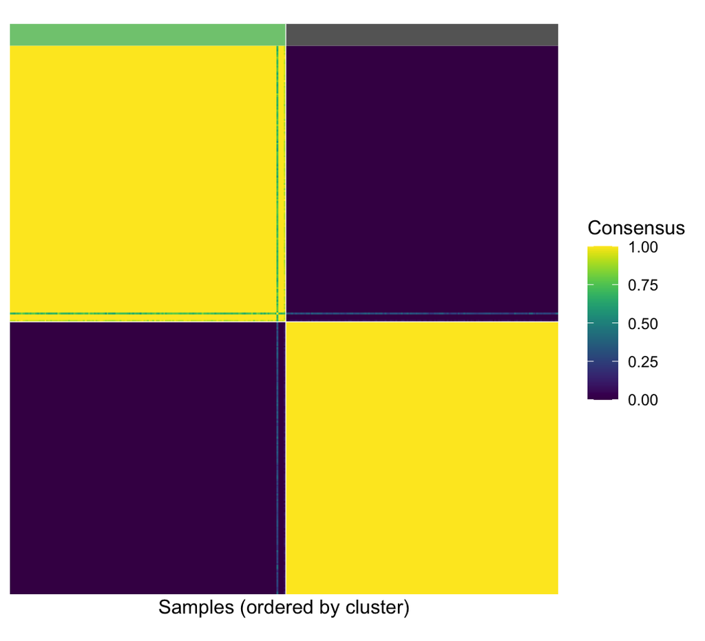

```r
plot_consensus_matrix(fit_line, k = 2)
```

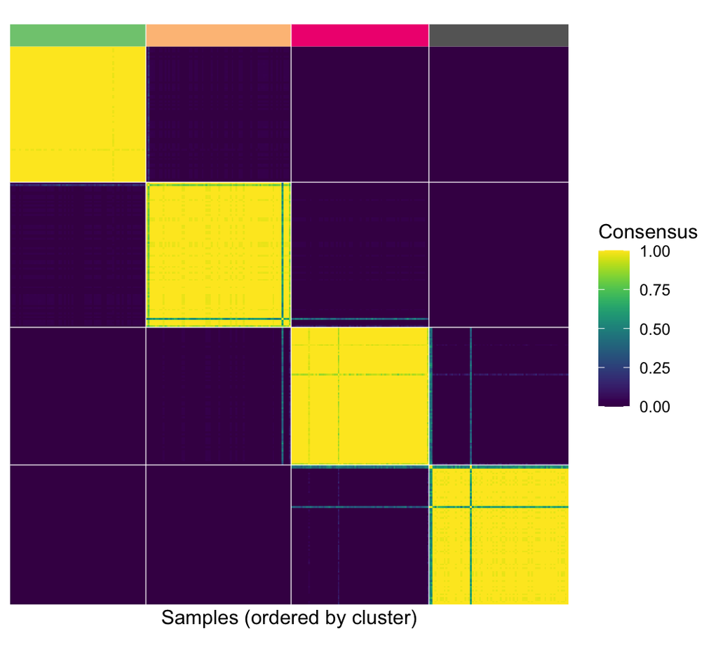

```r
plot_consensus_matrix(fit_line, rule = "max", not_two = TRUE)
```

The two-cluster consensus matrix looks clean, but it says little about the four groups. `not_two = TRUE` leaves two clusters out of the selection.

## Custom grids

`estimator_grid()` sets the methods and the values of their parameters:

```r
grids <- list(
  estimator_grid(KMeans, n_clusters = 2:8, n_init = 10),
  estimator_grid(AgglomerativeClustering, n_clusters = 2:8, linkage = c("ward", "single")),
  estimator_grid(SpectralClustering, n_clusters = 2:8, n_neighbors = c(5, 15))
)
fit_grid <- carve(moons, estimator_param_grids = grids, n_jobs = n_jobs, random_state = 42)
unique(estimator_results(fit_grid)$method_label)
```

```
#> [1] "KMeans, n_init=10"
#> [2] "AgglomerativeClustering, linkage=ward"
#> [3] "AgglomerativeClustering, linkage=single"
#> [4] "SpectralClustering, n_neighbors=5"
#> [5] "SpectralClustering, n_neighbors=15"
```

```r
get_k(fit_grid)
```

```
#> [1] 2
```

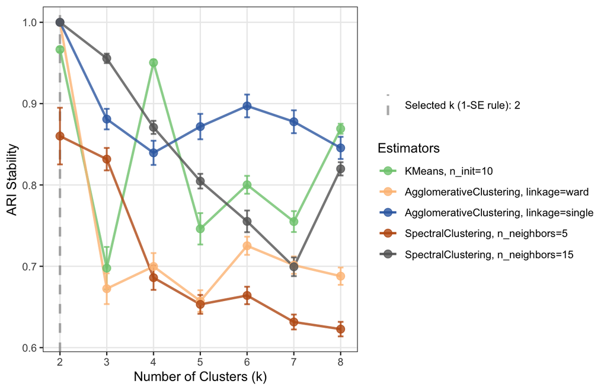

```r
plot_metric_over_n_clusters(fit_grid)
```

## Randomized preprocessing

k-means does not follow the curved shapes of the moons in their own coordinates. In the run below, half the resamples give it a t-SNE embedding to cluster. With `randomize_preprocessing = TRUE`, each resample draws a normalization and a dimensionality reduction from the options given and clusters the transformed subsamples; the classifier still trains on the raw coordinates.

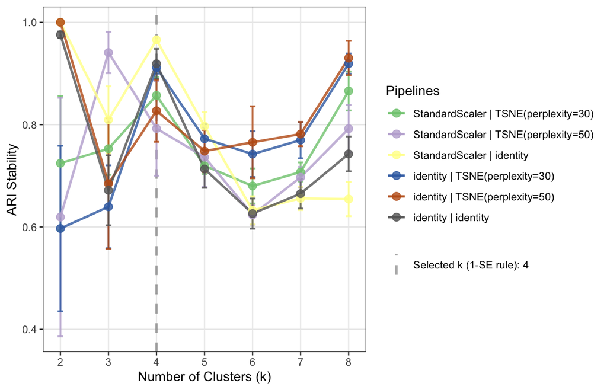

```r
fit_random <- carve(
  moons, randomize_preprocessing = TRUE, n_resamples = 60, n_jobs = n_jobs, random_state = 42,
  estimator_param_grids = list(estimator_grid(KMeans, n_clusters = 2:8)),
  normalization_options = list(preprocessing_option(Identity), preprocessing_option(StandardScaler)),
  dim_reduction_options = list(preprocessing_option(Identity), preprocessing_option(TSNE, perplexity = c(30, 50)))
)
plot_metric_by_pipeline(fit_random)
```

```r
pipeline_results <- preprocessing_results(fit_random)
pipeline_results[pipeline_results$n_clusters == 4,
                 c("pipeline", "n_resamples", "ari_stability", "ari_generalizability")]
```

```
#>                                pipeline n_resamples ari_stability
#> 3  StandardScaler | TSNE(perplexity=30)          10     0.8572272
#> 10 StandardScaler | TSNE(perplexity=50)           5     0.7924235
#> 17            StandardScaler | identity          15     0.9657359
#> 24       identity | TSNE(perplexity=30)          10     0.9114294
#> 31       identity | TSNE(perplexity=50)           5     0.8271515
#> 38                  identity | identity          15     0.9189815
#>    ari_generalizability
#> 3             0.7423326
#> 10            0.6810606
#> 17            0.8139259
#> 24            0.7799202
#> 31            0.7316693
#> 38            0.7887755
```

`preprocessing_results()` splits each configuration’s scores by pipeline. This run uses 60 resamples instead of 100 to save time, so each pipeline’s scores rest on 5 to 15 resamples (`n_resamples` in the table) and are noisy. At four clusters the pipelines with t-SNE do not score higher than the identity pipelines on these data.

## Saving a fit

```r
path <- file.path(tempdir(), "fit_moons.rds")
saveRDS(fit_moons, path)
reloaded <- readRDS(path)
identical(get_labels(reloaded, measure = "generalizability", rule = "1se", not_two = TRUE), moons_labels)
```

```
#> [1] TRUE
```

```r
round(file.size(path) / 2^20, 1)
```

```
#> [1] 11.6
```

The size is in MB. A fit keeps the data, so the scatter plots work on a fit read back from disk; Python’s `save()` leaves the data out unless `include_data=True`.

## Reference labels

Cluster numbers are arbitrary. `reference_labels` renames the clusters to match another labeling with the same number of clusters, here the truth:

```r
table(get_labels(fit_moons, k = 4, reference_labels = moons_truth), moons_truth)
```

```
#>    moons_truth
#>       1   2   3   4
#>   1 227  37   0   0
#>   2  23 213   0   0
#>   3   0   0 195   0
#>   4   0   0  55 250
```

`carve(reference_labels = )` sets the labeling for every `get_labels()` call on the fit.

## Parallel runs

A run clusters every configuration on every resample, so its cost grows with the number of configurations times `n_resamples`. `n_jobs` spreads each configuration’s resamples over worker processes; the results do not depend on it.

```r
blob_grid <- list(estimator_grid(KMeans, n_clusters = 2:8))
time_serial <- system.time(fit_serial <- carve(hard$X, estimator_param_grids = blob_grid, random_state = 0))
time_workers <- system.time(fit_workers <- carve(hard$X, estimator_param_grids = blob_grid, n_jobs = n_jobs, random_state = 0))
c(serial = time_serial[["elapsed"]], workers = time_workers[["elapsed"]])
```

```
#>  serial workers
#>   4.276   2.165
```

```r
all.equal(estimator_results(fit_serial), estimator_results(fit_workers))
```

```
#> [1] TRUE
```

Starting the workers has a cost of its own, so the gain grows with the work in each resample.

# Part 2: PBMC 3k

Single-cell data are usually clustered with Leiden or Louvain community detection on a nearest-neighbor graph of principal components. These methods take a resolution instead of a number of clusters. CARVE compares resolutions the way it compares numbers of clusters, and records, for each resolution, the mean number of clusters it gives over the resamples.

## Data and the Seurat workflow

The 10x Genomics PBMC 3k data, processed with the steps of Seurat’s tutorial:

```r
url <- "https://cf.10xgenomics.com/samples/cell/pbmc3k/pbmc3k_filtered_gene_bc_matrices.tar.gz"
dir.create("data", showWarnings = FALSE)
archive <- file.path("data", basename(url))
if (!file.exists(archive)) {
  utils::download.file(url, archive, mode = "wb")
}
matrix_dir <- file.path("data", "filtered_gene_bc_matrices", "hg19")
if (!dir.exists(matrix_dir)) {
  utils::untar(archive, exdir = "data")
}
```

```r
pbmc <- SeuratObject::CreateSeuratObject(
  counts = Seurat::Read10X(matrix_dir), project = "pbmc3k", min.cells = 3, min.features = 200
)
pbmc[["percent.mt"]] <- Seurat::PercentageFeatureSet(pbmc, pattern = "^MT-")
keep <- pbmc$nFeature_RNA > 200 & pbmc$nFeature_RNA < 2500 & pbmc$percent.mt < 5
pbmc <- subset(pbmc, cells = colnames(pbmc)[keep])
pbmc <- Seurat::NormalizeData(pbmc, verbose = FALSE)
pbmc <- Seurat::FindVariableFeatures(pbmc, nfeatures = 2000, verbose = FALSE)
pbmc <- Seurat::ScaleData(pbmc, verbose = FALSE)
pbmc <- Seurat::RunPCA(pbmc, npcs = 30, verbose = FALSE)
pbmc <- Seurat::FindNeighbors(pbmc, dims = 1:10, verbose = FALSE)
pbmc <- Seurat::FindClusters(pbmc, resolution = 0.5, verbose = FALSE)
pbmc <- Seurat::RunUMAP(pbmc, dims = 1:10, verbose = FALSE)
pbmc
```

```
#> An object of class Seurat
#> 13714 features across 2638 samples within 1 assay
#> Active assay: RNA (13714 features, 2000 variable features)
#>  3 layers present: counts, data, scale.data
#>  2 dimensional reductions calculated: pca, umap
```

The chunk hides Seurat’s own messages and warnings, such as its notice about the UMAP method; CARVE’s output is shown everywhere else.

## Comparing resolutions

```r
resolutions <- c(0.25, 0.5, 0.75, 1, 1.5)
fit_pbmc <- carve(pbmc, resolution = resolutions, n_dims = 10, n_jobs = n_jobs, random_state = 0)
fit_pbmc
```

```
#> CARVE fit on 2638 samples and 10 features
#> Sweep: resolution over 0.25, 0.5, 0.75, 1, 1.5
#> Estimators: LeidenClustering, LouvainClustering (10 configurations)
#> Resamples: 100 per configuration, subsample_ratio 0.618
#> Mode: default
#> Consensus: exact
```

`carve()` reads the first 10 principal components of the `"pca"` reduction, the ones Seurat’s graph used. With `resolution` given, it compares Leiden and Louvain at each resolution, each on a graph of the 15 nearest neighbors scaled to the subsample’s size.

```r
sweep_spec(fit_pbmc)
```

```
#> SweepSpec: resolution over 0.25, 0.5, 0.75, 1, 1.5 (larger values give more clusters)
```

```r
get_sweep_value(fit_pbmc)
```

```
#> [1] 0.25
```

```r
get_k(fit_pbmc)
```

```
#> [1] 5
```

`sweep_spec()` describes the sweep: the parameter, its values, and that larger values give more clusters. `get_sweep_value()` returns the selected resolution, and `get_k()` the number of clusters at it, rounded from the mean over the resamples.

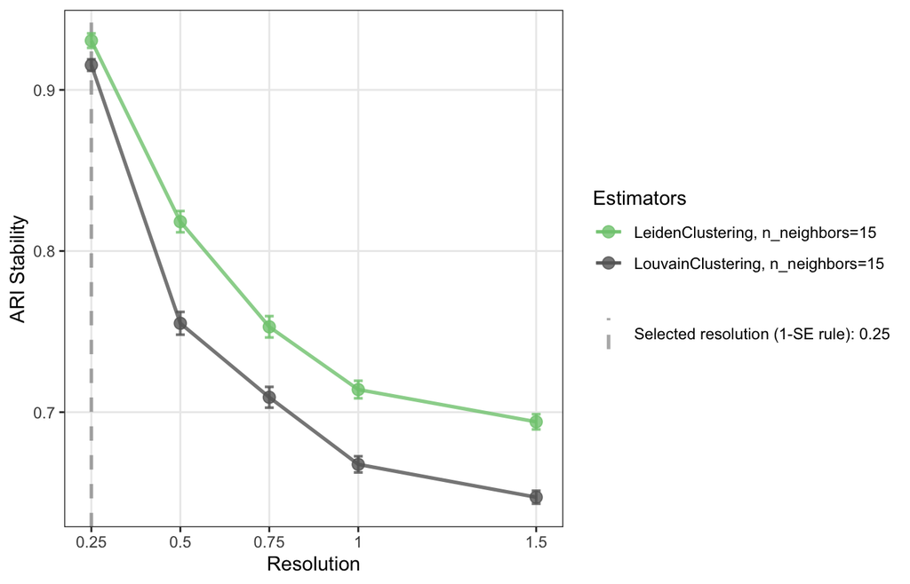

```r
plot_metric_over_n_clusters(fit_pbmc)
```

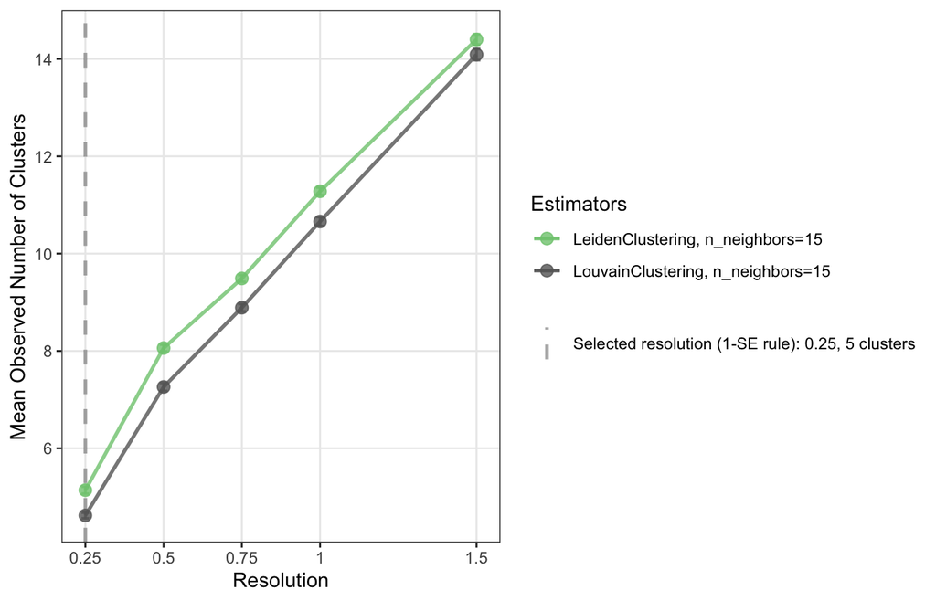

```r
plot_n_clusters_over_sweep(fit_pbmc)
```

The metric plot has the resolution on its x axis, one line per method. The second plot shows how many clusters each method found at each resolution.

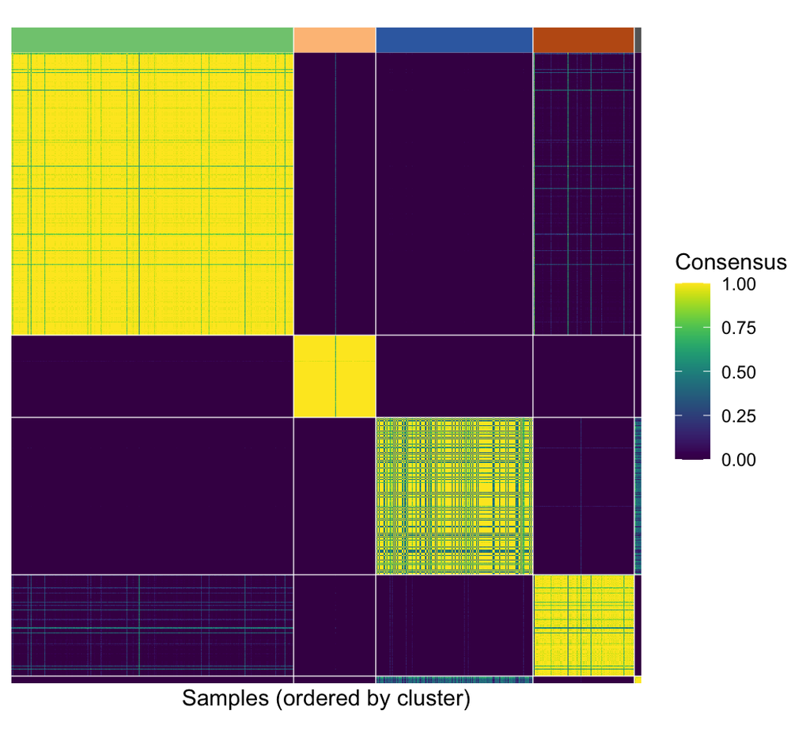

```r
plot_consensus_matrix(fit_pbmc)
```

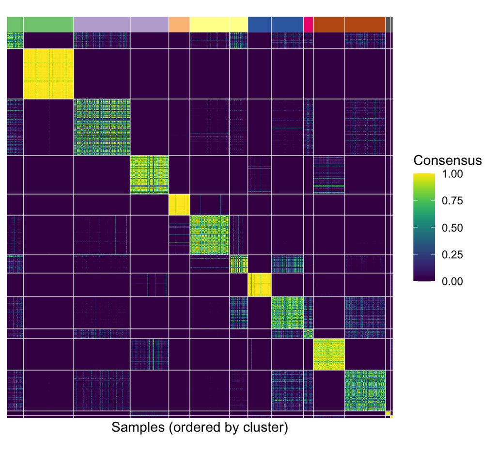

```r
plot_consensus_matrix(fit_pbmc, sweep_value = 1.5)
```

`sweep_value` pins a resolution in `get_labels()`, in the consensus plot and in the four per-sample plots. Below, the scatter plot on the UMAP and the violin plot are each drawn at the selected resolution and at the finest one:

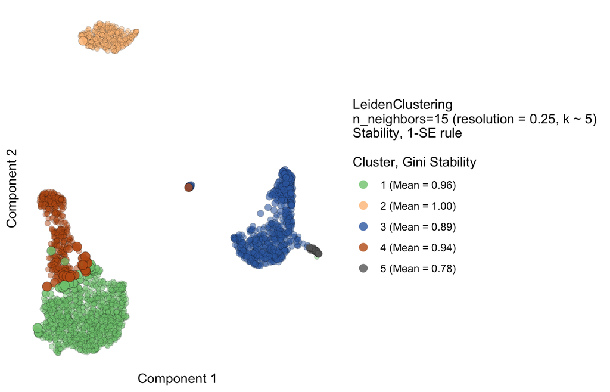

```r
umap <- SeuratObject::Embeddings(pbmc, reduction = "umap")
plot_cluster_scatter(fit_pbmc, embedding = umap)
```

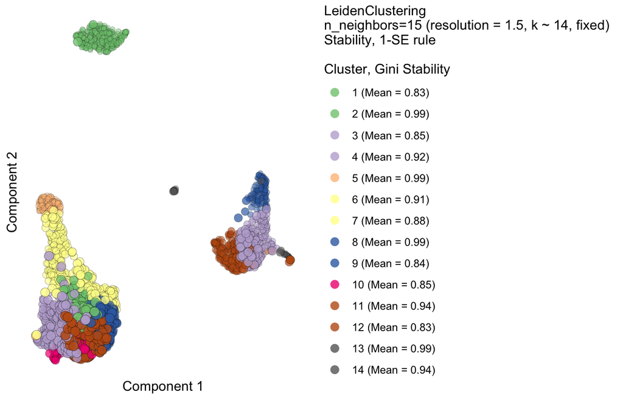

```r
plot_cluster_scatter(fit_pbmc, embedding = umap, sweep_value = 1.5)
```

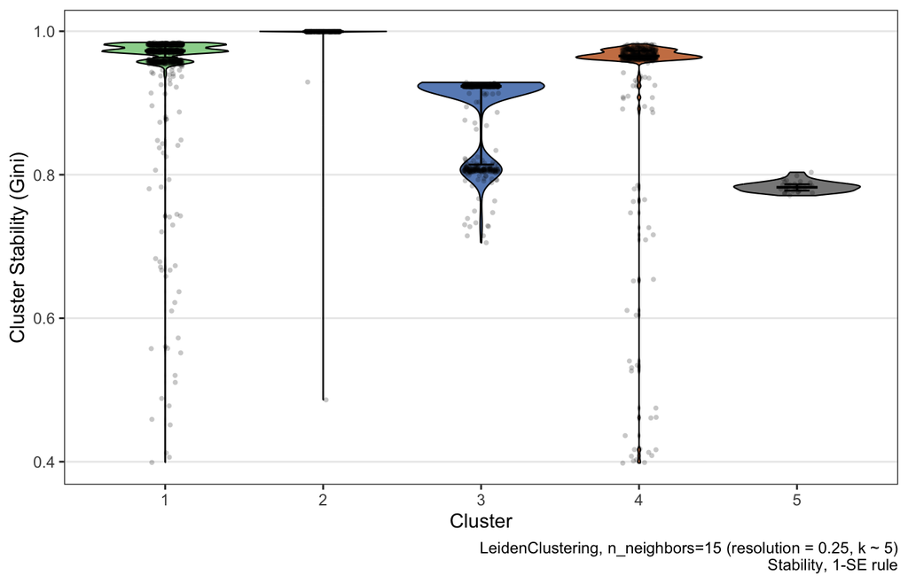

```r
plot_cluster_violin(fit_pbmc)
```

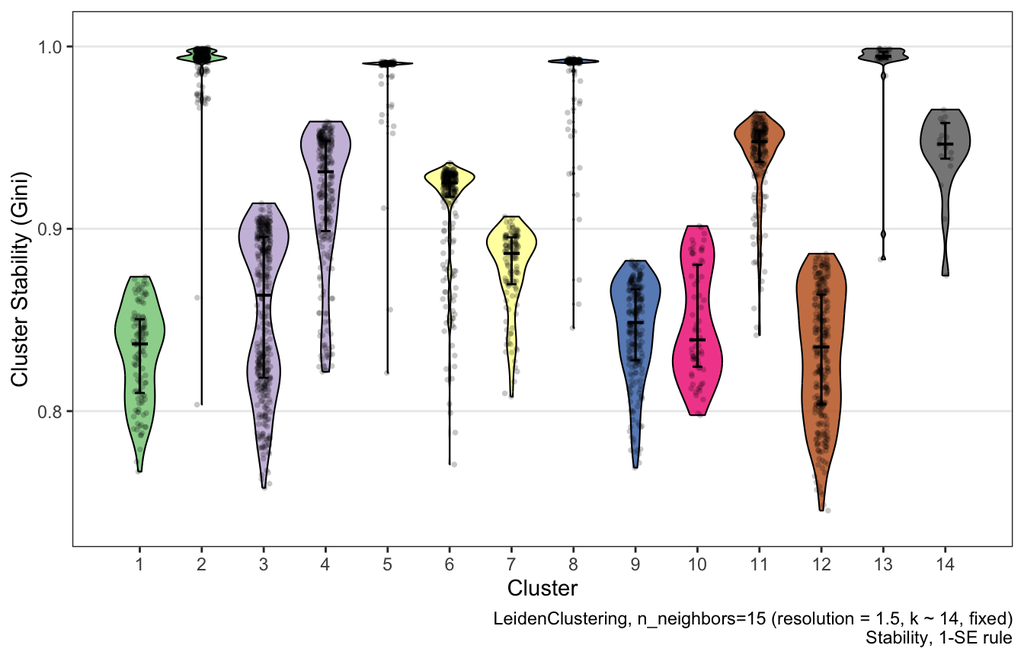

```r
plot_cluster_violin(fit_pbmc, sweep_value = 1.5)
```

The results table gains the sweep columns:

```r
results_pbmc <- estimator_results(fit_pbmc)
results_pbmc[, c("method_label", "resolution", "sweep_rank", "n_clusters_observed",
                 "ari_stability", "ari_generalizability")]
```

```
#>                         method_label resolution sweep_rank n_clusters_observed
#> 1   LeidenClustering, n_neighbors=15       0.25          0                5.14
#> 2   LeidenClustering, n_neighbors=15       0.50          1                8.06
#> 3   LeidenClustering, n_neighbors=15       0.75          2                9.49
#> 4   LeidenClustering, n_neighbors=15       1.00          3               11.28
#> 5   LeidenClustering, n_neighbors=15       1.50          4               14.40
#> 6  LouvainClustering, n_neighbors=15       0.25          0                4.62
#> 7  LouvainClustering, n_neighbors=15       0.50          1                7.26
#> 8  LouvainClustering, n_neighbors=15       0.75          2                8.89
#> 9  LouvainClustering, n_neighbors=15       1.00          3               10.66
#> 10 LouvainClustering, n_neighbors=15       1.50          4               14.09
#>    ari_stability ari_generalizability
#> 1      0.9305684            0.8807624
#> 2      0.8182311            0.7330988
#> 3      0.7529730            0.6778319
#> 4      0.7140395            0.6342114
#> 5      0.6940311            0.5903731
#> 6      0.9154029            0.8819104
#> 7      0.7551473            0.6984523
#> 8      0.7092420            0.6395950
#> 9      0.6676215            0.6072302
#> 10     0.6472272            0.5765397
```

`sweep_rank` orders the values from coarse to fine, and the selection rules work on it, so they behave the same on every axis. `n_clusters_observed` is the mean number of clusters over the resamples.

## Labels and Seurat’s clusters

```r
labels_pbmc <- get_labels(fit_pbmc)
table(CARVE = labels_pbmc, Seurat = pbmc$seurat_clusters)
```

```
#>      Seurat
#> CARVE   0   1   2   3   4   5   6   7   8
#>     1 684   0 476   0  22   0   0   0   0
#>     2   0   0   0 344   0   0   0   0   0
#>     3   0 481   0   0   0 162   0   2  13
#>     4   0   0   0   0 269   0 155   0   0
#>     5   0   0   0   0   0   0   0  30   0
```

```r
mclust::adjustedRandIndex(labels_pbmc, pbmc$seurat_clusters)
```

```
#> [1] 0.6235713
```

```r
table(get_labels(fit_pbmc, consensus_k = 4))
```

```
#>
#>    1    2    3    4
#> 1182  344  688  424
```

`consensus_k` cuts the selected consensus matrix into another number of clusters, to see how the cells group at a coarser level.

## Storing the results in the object

`attach_results()` writes the selected configuration into the Seurat object: the labels and the per-cell scores into the cell metadata, and the parameters, the results table and the consensus matrix into `pbmc@misc$carve`.

```r
pbmc <- attach_results(pbmc, fit_pbmc)
head(pbmc@meta.data[, c("seurat_clusters", "carve", "carve_stability", "carve_generalizability")])
```

```
#>                  seurat_clusters carve carve_stability carve_generalizability
#> AAACATACAACCAC-1               2     1       0.9843798              0.9210526
#> AAACATTGAGCTAC-1               3     2       0.9995703              1.0000000
#> AAACATTGATCAGC-1               2     1       0.9813629              0.9259259
#> AAACCGTGCTTCCG-1               1     3       0.9125420              0.8684211
#> AAACCGTGTATGCG-1               6     4       0.9747776              0.7500000
#> AAACGCACTGGTAC-1               2     1       0.9822839              0.9333333
```

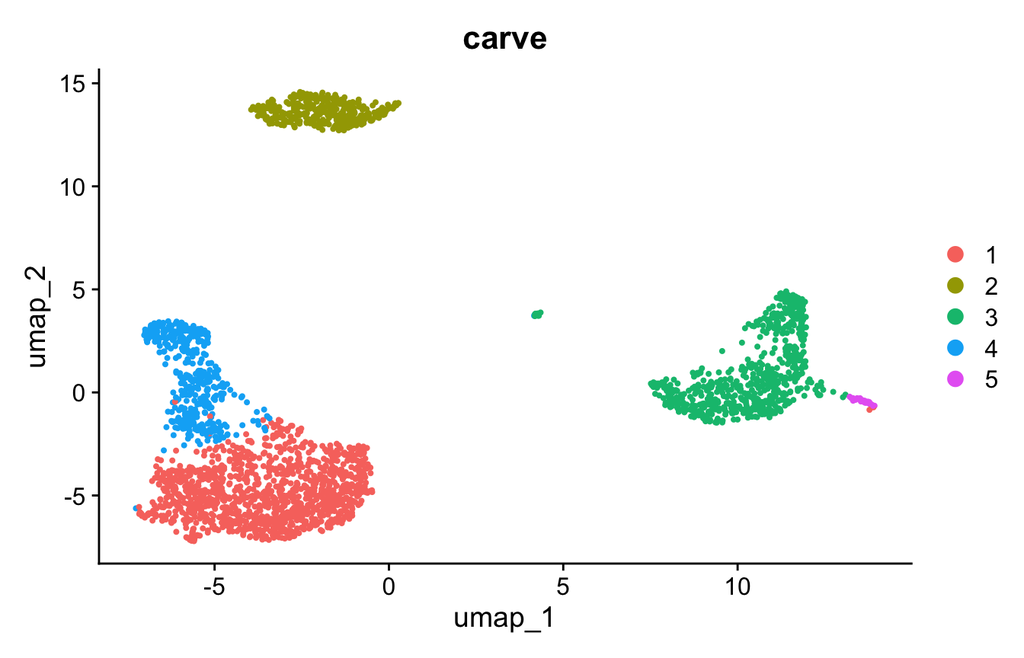

```r
Seurat::DimPlot(pbmc, group.by = "carve")
```

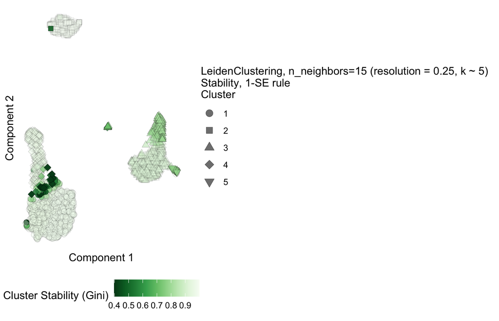

```r
plot_diagnostic_scatter(pbmc, basis = "umap")
```

`run_carve()` does both steps in one call. On a SingleCellExperiment made from the same object, with the same seed, it gives the same labels:

```r
sce <- Seurat::as.SingleCellExperiment(pbmc)
SingleCellExperiment::reducedDimNames(sce)
```

```
#> [1] "PCA"  "UMAP"
```

```r
sce <- run_carve(sce, resolution = resolutions, n_dims = 10, n_jobs = n_jobs)
identical(as.character(sce$carve), as.character(pbmc$carve))
```

```
#> [1] TRUE
```

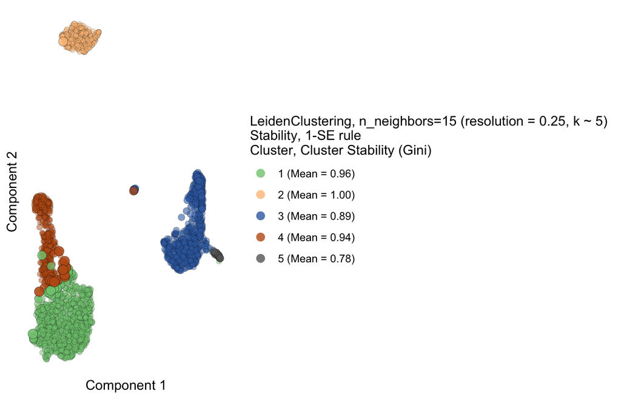

```r
plot_cluster_scatter(sce, basis = "UMAP")
```

## Ambiguous cells

```r
noisy <- get_labels(fit_pbmc, noise_labels = TRUE, noise_quantile = 0.05)
table(noisy)
```

```
#> noisy
#>   -1    1    2    3    4
#>  132 1149  343  620  394
```

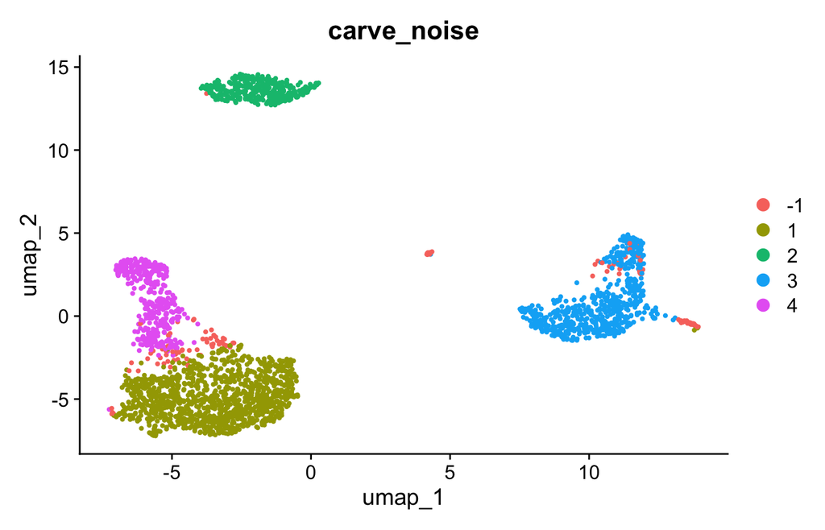

```r
pbmc$carve_noise <- factor(noisy)
Seurat::DimPlot(pbmc, group.by = "carve_noise")
```

`noise_labels = TRUE` labels -1 the cells whose stability is in the lowest 5 percent and more than 0.05 below the median.

## HDBSCAN

HDBSCAN takes a minimum cluster size and labels cells in sparse regions -1. It needs the dbscan package.

```r
pcs <- SeuratObject::Embeddings(pbmc, reduction = "pca")[, 1:10]
hdbscan_grid <- list(estimator_grid(HDBSCAN, min_cluster_size = c(10, 20, 40, 80)))
fit_hdbscan <- carve(pcs, estimator_param_grids = hdbscan_grid, n_jobs = n_jobs, random_state = 0)
sweep_spec(fit_hdbscan)
```

```
#> SweepSpec: min_cluster_size over 10, 20, 40, 80 (smaller values give more clusters)
```

```r
estimator_results(fit_hdbscan)[, c("min_cluster_size", "n_clusters_observed", "noise_fraction", "ari_stability")]
```

```
#>   min_cluster_size n_clusters_observed noise_fraction ari_stability
#> 1               10                3.23     0.07804294     0.8392651
#> 2               20                3.11     0.11098773     0.9925043
#> 3               40                3.00     0.13135583     0.9996580
#> 4               80                3.00     0.18758896     0.9997097
```

```r
get_sweep_value(fit_hdbscan)
```

```
#> [1] 40
```

From the grid, CARVE infers that `min_cluster_size` is swept and that larger values give fewer clusters. `noise_fraction` is the share of cells labeled noise, averaged over the resamples. By default, `noise_policy = "drop"` leaves noise cells out of each resample’s scores.

## Graph methods on their own, and neighborhood sizes

`LeidenClustering()` and `LouvainClustering()` are plain functions:

```r
table(LeidenClustering(pcs, resolution = 0.5, random_state = 0))
```

```
#>
#>   1   2   3   4   5   6   7   8
#> 311 344 449 480 143 178 703  30
```

```r
table(LouvainClustering(pcs, resolution = 0.5, random_state = 0))
```

```
#>
#>   1   2   3   4   5   6   7
#> 373 344 458 548 142 632 141
```

A grid can vary the graph as well as the resolution. CARVE infers the resolution sweep from the grid:

```r
neighbor_grid <- list(estimator_grid(LeidenClustering, resolution = resolutions, n_neighbors = c(10, 15, 30)))
fit_neighbors <- carve(pcs, estimator_param_grids = neighbor_grid, n_jobs = n_jobs, random_state = 0)
sweep_spec(fit_neighbors)
```

```
#> SweepSpec: resolution over 0.25, 0.5, 0.75, 1, 1.5 (larger values give more clusters)
```

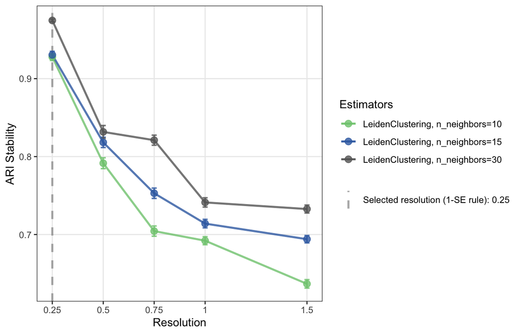

```r
plot_metric_over_n_clusters(fit_neighbors)
```

## Randomized preprocessing

The principal components above are one choice of preprocessing. With `randomize_preprocessing = TRUE`, CARVE draws a pipeline for each resample and fits it on the subsamples, here on the log-normalized expression of the 2,000 variable genes. On macOS and Linux the default backend forks the R session. After Seurat’s PCA had run in this session, the forked workers of this fit crashed, so this fit passes a socket backend through `BPPARAM`:

```r
genes <- SeuratObject::VariableFeatures(pbmc)
expression <- t(as.matrix(SeuratObject::LayerData(pbmc, layer = "data")[genes, ]))
dim(expression)
```

```
#> [1] 2638 2000
```

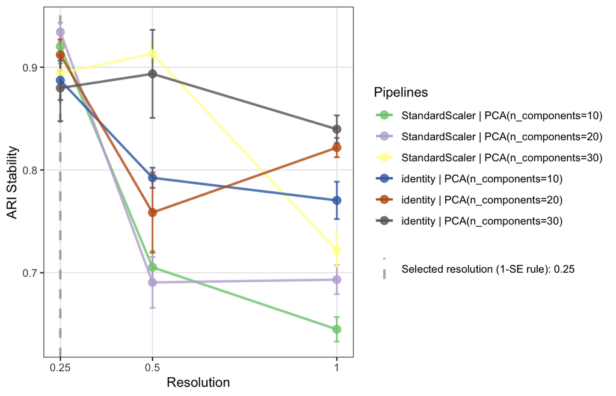

```r
fit_random_pbmc <- carve(
  expression, randomize_preprocessing = TRUE, n_resamples = 60, n_jobs = n_jobs, random_state = 0,
  BPPARAM = BiocParallel::SnowParam(workers = n_jobs),
  estimator_param_grids = list(estimator_grid(LeidenClustering, resolution = c(0.25, 0.5, 1))),
  normalization_options = list(preprocessing_option(Identity), preprocessing_option(StandardScaler)),
  dim_reduction_options = list(preprocessing_option(PCA, n_components = c(10, 20, 30)))
)
plot_metric_by_pipeline(fit_random_pbmc)
```

`pipeline_from_spec()` applies a pipeline to all the cells, for example the one with the highest stability:

```r
pipeline_results <- preprocessing_results(fit_random_pbmc)
best <- pipeline_results$pipeline[which.max(pipeline_results$ari_stability)]
best
```

```
#> [1] "StandardScaler | PCA(n_components=20)"
```

```r
embedding <- pipeline_from_spec(preprocessing_pipelines(fit_random_pbmc)[[best]], random_state = 0)(expression)
dim(embedding)
```

```
#> [1] 2638   20
```

# Session information

This rendering took 10 minutes on 10 cores.